# COMPSCI 527 Homework 1

## Homework Submission Workflow

When you submit your work, follow the instructions on the [submission workflow page](https://www.cs.duke.edu/courses/spring24/compsci527/homework/workflow.html) **scrupulously** for full credit.

### Problem 0 (3 points)

Is this assignment properly formatted in the PDF submission, and did you tell Gradescope accurately where each answer is?

#### Note

This question requires no explicit answer from you, and no space is provided for an answer in the template file.

However, the rubric entry for this problem in Gradescope will be used to deduct points for poor formatting of the assignment (PDF is not readable, code or text is clipped, math is not typeset, ...) and for incorrect indications in Gradescope for the location of each answer.

Sorry we have to do this, but poor formatting and bad answer links in Gradescope make our grading much harder.

## Part 1: Correlation and Convolution Basics

Let

$$ I = \left[\begin{array}{rrrrr} 2 & 1 & -3 & 4 & 1 & 2 \end{array}\right] \;\;\;\text{,}\;\;\; H = \left[\begin{array}{ccc} 2 & -1 & 3 \end{array}\right] $$

be an "image" and a "kernel" respectively.

In the problems that follow, pay attention to the difference between convolution and correlation. When padding is needed, pad with zeros distributed symmetrically around $I$ in this Part. *Do all calculations by hand in this Part.*

#### Note

It may be tempting to use software for these calculations. This choice has two issues:

- It constitutes cheating, because the problem asks you to do the calculations by hand.
- You would not be prepared to answer similar or related questions in exams, and more generally your understanding of the relevant concept would be weak.

The calculations may be tedious, but the point is to get you to do enough of them so that they sink in permanently. If you do this, you won't have any residual doubts as to what needs to be done.

After completing the calculations by hand, you may check the results with software and correct them if needed. Do *not* hand in your checks.

#### Matrices in LaTeX

One way to render

$$ X = \left[\begin{array}{rrr} 1 & -2 & 3 \\ -4 & 5 & -6 \end{array}\right] $$

in math mode (that is, between single or double dollar signs), is to write

```
X = \left[\begin{array}{rrr}
    1 & -2 & 3 \\
    -4 & 5 & -6
\end{array}\right]
```

When matrices are row vectors, you can choose this same format, or just use brackets (or parentheses) and commas. That is, all of the following formats are acceptable:

$$ Z = \left[\begin{array}{rrr} 1 & -2 & 3 \end{array}\right] \;\;\;,\;\;\; Z = [1, -2, 3] \;\;\;,\;\;\; Z = (1, -2, 3) $$

### Problem 1.1 (Exam Style)

Write the numerical values of the following arrays:

- The array $F$ resulting from the 'full' correlation of $I$ and $H$.
- The array $V$ resulting from the 'valid' correlation of $I$ and $H$.
- The array $S$ resulting from the 'same' correlation of $I$ and $H$.

#### Hints

- You obtain the same result regardless of whether you consider these to be correlations in one dimension or in two.
- Once you have $F$, little extra effort is needed to find $V$ and $S$. Make sure you get $F$ right, or else you get penalized multiple times for the same mistake.

### Problem 1.2 (Exam Style)

Write the numerical values of the following arrays:

- The array $F$ resulting from the 'full' convolution of $I$ and $H$.
- The array $V$ resulting from the 'valid' convolution of $I$ and $H$.
- The array $S$ resulting from the 'same' convolution of $I$ and $H$.

### Problem 1.3 (Exam Style)

Compute the 'same' convolution $C$ of

$$ A = \left[\begin{array}{rrrr} 4 & 2 & 3 & 0 \\ 2 & 1 & 5 & 1 \\ 2 & 3 & 0 & 1 \end{array}\right] $$

with

$$ B = \left[\begin{array}{rrr} 3 & 1 & 0\\ 0 & 4 & 1\\ 2 & 0 & 3 \end{array}\right] \;. $$

## Part 2: Differentiation Basics

Consider the following toy image:

$$ I = \left[\begin{array}{ccccc} 0 & 24 & 16 & 40 \\ 24 & 32 & 40 & 48 \\ 48 & 32 & 16 & 0 \\ 16 & 16 & 16 & 16 \end{array}\right] \;. $$

#### Coordinate Notation

To avoid confusion with coordinates we index pixels in this image as $I(r, c)$, where $r$ is the row index and $c$ is the column index, consistently with standard matrix indexing conventions. In this part it is not relevant whether $r$ and $c$ start at 0 or 1. When we program later in this assignment, indices will start at zero for consistency with Python indexing.

The "horizontal derivative" is the derivative with respect to $c$. A derivative in this direction is positive when image values increase as we go to greater column indices ("to the right" in the image).

The "vertical derivative" is the derivative with respect to $r$. A derivative in this direction is positive when image values increase as we go to greater row indices ("down" in the image).

When giving a discrete estimate of the gradient of $I$ we give the horizontal derivative $I_c$ first and the vertical derivative $I_r$ second. These are two arrays.

We will use this notation consistently throughout this assignment.

#### Using Software

The same considerations about using software hold here as for Part 1. In short, don't.

#### Notes

- Corresponding results from different differentiation schemes in this Part may look quite different from each other. This is because the image $I$ is very small and contains nearly random values. Results would be more consistent (although still somewhat different) if larger and smoother input images were used.
- Some problems in this Part are linked, so any mistakes you make in the math in an earlier problem may propagate to subsequent problems. This will result in multiple penalties for a single mistake. So be careful with the math.

### Problem 2.1 (Exam Style)

Give the two matrices $I_c$ and $I_r$ found by computing the gradient with central differences and using the `'same'` style of convolution (recall that central differences are indeed convolutions). Pad symmetrically with zeros as needed.

### Problem 2.2 (Exam Style)

We saw that using the `'valid'` convolution is inconvenient because the shape of the output is different from that of the input. What would be an additional difficulty if the `'valid'` convolution were used when computing the gradient with central differences, as you did in the previous problem?

### Problem 2.3 (Exam Style)

Padding with zeros, as you did in Problem 2.1, amounts to placing a black rim (in images, the pixels that are zero appear as black) on some sides of the input image. This causes artificially high values in the derivatives near image boundaries in most cases.

A better way when differentiating is to pad by replication instead, which amounts to repeating the nearest row or column rather than adding zeros. This typically causes less abrupt derivative values near the boundaries (although this will be hard to see with the random values in the image $I$ for this part).

#### Your Task

Recompute $I_r$ and $I_c$ as in Problem 2.1 (that is, with the `'same'` convolution) but padding by replication rather than with zeros.

### Problem 2.4 (Exam Style)

Compute new estimates $I'_c$ and $I'_r$ for the gradient of the matrix $I$ given in this Part using the Sobel filter instead of central differences. Pad by replication.

*For full credit, use separability and explain briefly but clearly how you can use the results from the previous problem to simplify your job here.*

## Part 3: Gaussian Differentiation

### Problem 3.1

Write Python functions with headers

```
def gaussian(sigma, trunc_multiple=3.5):
```

and

```
def d_gaussian(sigma, trunc_multiple=3.5):
```

that compute a one-dimensional normalized Gaussian kernel and its normalized derivative. Both kernels use the given parameter `sigma` for the Gaussian and are truncated roughly at $\sigma\tau$ where $\sigma$ is `sigma` and $\tau$ is `trunc_multiple`.

More precisely, `gaussian` computes a `numpy` vector `g` of $n$ floating-point samples where $n = 2h + 1$ and $h = \lceil\sigma\tau\rceil$ (the notation $\lceil\cdot\rceil$ denotes the ceil function). The samples are computed and normalized as specified in the [class notes](https://canvas.duke.edu/courses/23637/files). The resulting vector is an averaging (or smoothing) kernel.

The function `gaussian` returns both `g` and a `numpy` vector `x` equal to `np.arange(-h, h+1)`. This is the vector of coordinates on which the values of the Gaussian are computed.

The function `d_gaussian` is similar but returns `d` and `x` where `d` is the Gaussian differentiation kernel, computed and normalized as specified in the notes.

#### Your Task

Consider the following signal:

$$ s(t) = \sin\left(\pi\frac{t}{T}\right)^2 \;\;\;\mbox{where}\;\;\; T = 50 $$

and for integer values of $t$ in $[-T, T]$.

First show an expression for the exact derivative $s'(t)$ of $s(t)$ (use the expression you get from calculus in your code).

Then show your code and the following plots for $\sigma = 3$:

- Two side-to-side diagrams (`pyplot.subplot(1, 2, k))` with the following two plots, where each sample on the plot is a dot:
  - A plot of `g = gaussian(sigma)`.
  - A plot of `d = d_gaussian(sigma)`.
- The following four plots (arranged in any way you like, but in this order), obtained with $\sigma = 3$ and $T = 50$, and where each plot is displayed as a continuous curve:
  - A plot of $s(t)$.
  - A plot of $s(t)$ smoothed with `g`.
  - A plot of the derivative $ds(t)$ of $s(t)$ computed numerically by convolution with the kernel `d`.
  - A plot of the difference between $ds(t)$ and the true derivative $s'(t)$.

#### Notes

- Use `valid` convolutions. When you display the signal $s(t)$, truncate it so that it has the same number of samples as the smoothed version and the derivative.
- Use `numpy.convolve` for convolutions.
- Use `x` returned by `gaussian` to plot the abscissas for the first two plots. The `x` returned by `d_gaussian` is the same.
- Use integer abscissas in the appropriately truncated portion of $[-T, T]$ for the other four plots.
- Be modular. For instance, write a single function that computes the plot of a signal (one of the last four plots) and call that four times, rather than cutting and pasting code.
- Draw a horizontal line at value 0 for the last four plots, so it is clear where the plot values are positive and where they are negative.
- Put a title above each plot.
- The difference between computed and true derivative will be small near $t = 0$ but will be larger at the tails. If your difference is not small (compared to the values of the true derivative) for, say $t\in[-10, 10]$, then you probably have a mistake somewhere.

### Problem 3.2

Why does the error in the derivative increase towards the tails? That is, what key assumption underlying the computation of derivatives with Gaussian differentiation kernels is violated more for large values of $|t|$?

### Problem 3.3

Add random Gaussian noise with zero mean and standard deviation $0.05$ to $s(t)$. Then compute the derivative of the noisy signal with the same kernel `d` used earlier as well as with central differences. For each type of derivative computation, display the difference between the computed derivative and the exact derivative $s'(t)$.

In addition, comment briefly on which kernel you would use when the signal is noisy, and provide reasons for why that choice works better.

## Part 4: Image Gradient

The code below retrieves an image called `shadow.png`, reads it into variable `shadow`, and displays it. It also converts the image from `np.uint8` to `float` so that we can use floating-point operations on it.

```python
import urllib.request
import ssl
from os import path as osp
import shutil

def retrieve(file_name, semester='spring24', homework=1):
    if osp.exists(file_name):
        print('Using previously downloaded file {}'.format(file_name))
    else:
        context = ssl._create_unverified_context()
        fmt = 'https://www2.cs.duke.edu/courses/{}/compsci527/homework/{}/{}'
        url = fmt.format(semester, homework, file_name)
        with urllib.request.urlopen(url, context=context) as response:
            with open(file_name, 'wb') as file:
                shutil.copyfileobj(response, file)
        print('Downloaded file {}'.format(file_name))
```

```python
from skimage.io import imread

retrieve('shadow.png')
shadow = imread('shadow.png').astype(float)
```

```
Using previously downloaded file shadow.png
```

```python
import numpy as np
from matplotlib import pyplot as plt
%matplotlib inline

def show_image(image, cmap='gray'):
    aspect = image.shape[0] / image.shape[1]
    width = 6
    height = width * aspect
    plt.figure(figsize=(6, height), tight_layout=True)
    plt.imshow(image, cmap=cmap)
    plt.axis('image')
    plt.axis('off')
    plt.colorbar()
    plt.draw()
```

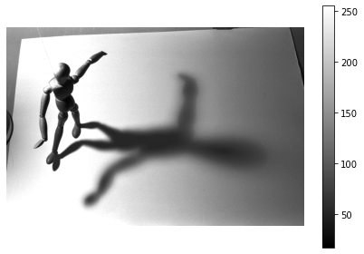

```python
show_image(shadow)
```

### Problem 4.1

Use the functions `gaussian` and `d_gaussian` as well as the function `scipy.ndimage.convolve` to implement a function with header

```
def gradient(image, sigma):
```

that returns the gradient `(gc, gr)` of the given `image` using `sigma` as the parameter for the kernels. Use separability for efficiency and **for full credit**.

Then use `matplotlib.pyplot.imshow` to display the two arrays `gc` and `gr` that constitute the gradient of `shadow.png` computed with $\sigma=2$.

Show the two arrays side by side. Use the colormap `'RdBu'` and put a colorbar next to each image, so the colors can be interpreted. Refer to `show_image` above to see how that is done. Give each image a title.

### Problem 4.2

Display the magnitude of the gradient you just computed. Use `show_image` with the `'viridis'` colormap.

Explain briefly why some gradients are stronger than others along the mannequin shadow in this image. Refer to how the scene is lit in your explanation.

### Problem 4.3

Use the interpolation function `scipy.interpolate.interpn` to write a function with header

```
def ridges(g, thr):
```

This function takes a gradient pair `g = (gc, gr)` for some black-and-white image and a nonnegative threshold `thr` and returns a binary map of all strong gradient ridge points in the image. These points are defined next.

Let $m$ be the magnitude of the gradient $\mathbf{g}$, and let $t$ be the threshold `thr`. A pixel at row $r$ and column $c$ is a *strong gradient ridge point* if it satisfies the following conditions:

- $m(r, c) \geq t$ and $m(r, c) > 0$.
- The point $(r, c)$ is at least one pixel away from the nearest image boundary.
- The gradient magnitude $m(r, c)$ in the direction of the gradient $\mathbf{g}(r, c)$ at $(r, c)$ is a local maximum. This can be determined as follows:
  - Let $\mathbf{p} = (r, c)$.
  - Let $\mathbf{n} = \mathbf{g}(\mathbf{p}) / \|\mathbf{g}(\mathbf{p})\|$ be a unit vector in the direction of the gradient at $\mathbf{p}$. Since $m(\mathbf{p}) > 0$, this vector is well defined.
  - Determine the two points $\mathbf{a} \text{ and } \mathbf{b}$ where $\mathbf{a} = \mathbf{p} + \mathbf{n}$ and $\mathbf{b} = \mathbf{p} - \mathbf{n}$ that are one pixel away from $\mathbf{p}$ in the positive and negative direction of the gradient. These two points are determined by bilinear interpolation.
  - The point $\mathbf{p}$ is a local maximum for $m$ in the direction of the gradient if $m(\mathbf{p}) > m(\mathbf{a})$ and $m(\mathbf{p}) > m(\mathbf{b})$. That is, walking from $\mathbf{a}$ through $\mathbf{p}$ and to $\mathbf{b}$ you first go uphill and then downhill.

#### Notes

- It may take a bit of patience to parse the definition of strong ridge point above. You may want to make a drawing for yourself to understand what is going on.
- This problem is more an exercise in `numpy` than anything else. Use matrix operations without explicit `for` loops, or your program wil take forever. Here is one possible strategy, but this is not mandatory:
  - Compute the gradient magnitude $m$ as a single array.
  - Find the indices of all the points that are at least one pixel away from the image boundaries and where $m \geq t$. We found the function `numpy.flatnonzero` useful here.
  - Find two vectors `rows` and `columns` with the coordinates of all those points. We found `numpy.unravel_index` useful here.
  - Flatten the valid parts of $m$, $g_r$, and $g_c$ into vectors using `numpy.ravel()`.
  - Compute the unit vectors $\mathbf{n}$ (all at once, no explicit `for` loops).
  - Compute the points $\mathbf{a}$ and $\mathbf{b}$ (*ditto*).
  - Use `scipy.interpolate.interpn` to find the values of $m$ at those points.
  - The rest is simple.
- Read the specification of `scipy.interpolate.interpn` very carefully, paying particular attention to the required shapes of the arguments `points` and `xi`. The formats of these two arguments are different, and you may need some combination of `numpy` functions such as `arange`, `linspace`, `meshgrid`, and/or `column_stack` to make values to pass to these arguments.

#### Your Task

- Show your code.
- Use `show_image` to display the ridge points in the gradient of `shadow`, computed first with threshold 0 and then with threshold 5.
- Comment briefly on why finding the contours of the shadow is difficult, and suggest how one might go about doing that. No implementation needed here. We are not looking for a complete solution, just some general strategic principle.

## Part 5: Image Resizing and Pyramids

### Problem 5.1

Use the function `gaussian` you wrote earlier, together with the interpolation function `scipy.interpolate.interpn`, to write a function with header

```
def resize(image, spec):
```

that resizes the (black-and-white) `image` according to the specifications in `spec`:

- If `spec` is a single number, it is a magnification factor $\phi$, as explained in the [notes](https://canvas.duke.edu/courses/23637/files?). If $0 < \phi < 1$, the image shrinks, and appropriate smoothing must be applied before subsampling by bilinear interpolation (option `method='linear'` in `interpn`). If $\phi \geq 1$, the image increases in size, and no smoothing is to be performed.
- If `spec` is a pair of positive integers, `spec = (rows, columns)`, the function `resize` outputs an image of shape `spec`. Note that this requires possibly different magnification factors for the horizontal and the vertical dimensions. Perhaps the image shrinks in one dimension but grows in the other, and then the appropriate handling needs to occur as specified in the previous bullet, and separately for each dimension and its own magnification factor $\phi$.

#### Note

You may *not* use any library function that resizes images (such as `skimage.transform.resize` or similar functions). The point here is for you to learn how to do the resizing yourself.

#### Your Task

Show your code and the result of resizing `shadow` to an image of shape `(300, 1000)`. Use `show_image` with the default colormap.

### Problem 5.2

Use your function `resize` to implement a function with header

```
def gaussian_pyramid(image, phi=1/2):
```

that returns a pyramid for the given `image` and with the given magnification factor `phi` between 0 and 1 exclusive. The pyramid is stored as a list of images, with the original image first.

Then use `show_image` with the default colormap to display a composite image of the pyramid of `shadow` with the default value of `phi`. The composite is in the same style as the pyramid shown in the [class notes](https://canvas.duke.edu/courses/23637/files). When assembling the composite, you may assume that $\phi \leq 1/2$.